# Au-delà du code

Accompagner les équipes dans la transition vers l’open source

Raphaël Simon, Vincent Biot, Nathalie Rigollot, Meriem Saïd  
ATIH

16 juin 2026

## L’ATIH en bref

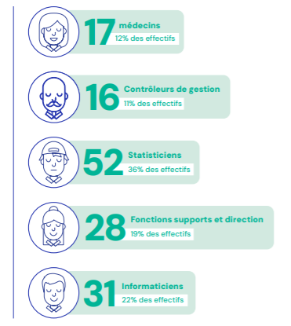

- Missions : collecte, analyse et diffuse les données hospitalières
- Large volume et flux quotidien de données
- Systèmes critiques en production
- Partenaires : établissements, ARS, DGOS, DREES, chercheurs, industriels

##### 2023 : lancement du projet “alternatives”

## Changer de logiciel

Logiciel propriétaire 👑

↓

[figure not shown]

[figure not shown]

[figure not shown]

## Changer de logiciel

[figure not shown]

20 %

outil

80 %

Humain

# Accompagner le changement

[figure not shown]

## Gouvernance

[figure not shown]

classique comité stratégique  
la direction décide et arbitre

classique groupe projet  
un relais dans chaque service

nouveau catalyseurs  
veiller, creuser, tester, proposer, secouer

## Identité professionnelle

ingénieur statisticien

## Identité professionnelle

ingénieur statisticien

↓

ingénieur statisticien

data scientistmodéliser

data analystanalyser

data engineerintégrer

DBAadministrer

chef de projetorchestrer

# Accompagner la montée en compétence

## Monter, mais pas en escalier

[figure not shown]

## Investir dans l’individu

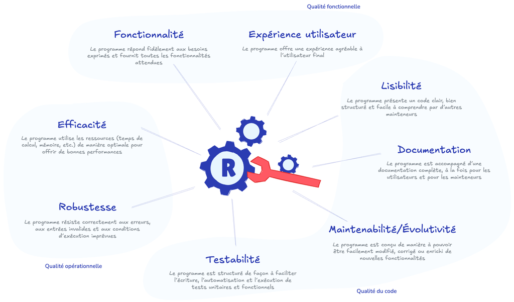

thinkr.fr

# Infrastructure

## Des contraintes spécifiques

avant

Code

Son Altesse 👑

OS & libs système

Infrastructure

➜

maintenant

Code

Packages

Version R / Python

OS & libs système

Infrastructure

environnement contraint

Ø internet on-prem Citrix Volumétrie Kubernetes VM

solutions maison

Teradata DuckDB Parquet Packages internes CI/CD renv Droits Binaires Ressources

[figure not shown]

## Embrasser la culture informatique

[figure not shown]

🔀

versionner & partager

GitCIforge

🔁

reproduire

versionsenvironnements

🧩

factoriser

fonctionspackages

25 ans de programmes : rien ne se traduit tout seul

[figure not shown]

**À voir dans quelques minutes !**

[50 milliards d’euros, une deadline, zéro régression : migrer un service de calcul critique vers R avec l’IA](https://rr2026.sciencesconf.org/718315)

## Et ensuite ?

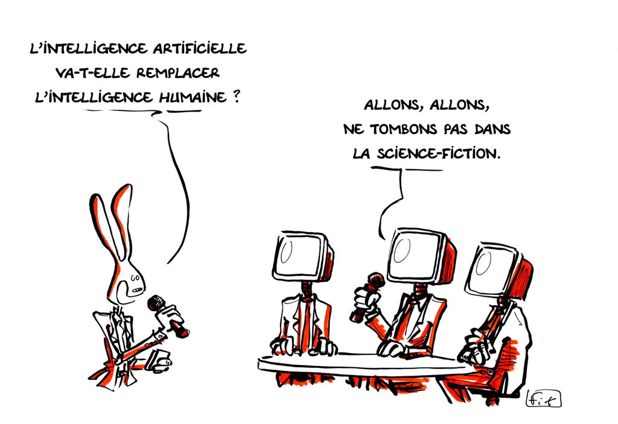

Merci

raphael.simon@atih.sante.fr